MARRUECOS  
[S.G de Análisis migratorio](https://www.inclusion.gob.es/web/opi/estadisticas)  
31/05/2023

1. Ciudadanos con documentación de residencia en vigor  
2. Otros documentados y estimación de personas sin documentación de residencia  
3. Perfil socio-demográfico y distribución territorial  
4. Afiliación en alta laboral y paro registrado  
5. Nacionalizados españoles por residencia  
6. Solicitantes de Protección Internacional  
7. Beneficiarios del sistema de acogida  
8. Menores no acompañados registrados en el Registro MENAs  
9. Evolución de los flujos regulares (visados y documentación de residencia)  
10. Población española residente en Marruecos

# 1. Ciudadanos con documentación de residencia en vigor

A fecha 31/12/2022 constaban **844.943 ciudadanos de nacionalidad marroquí con documentación de residencia en vigor en España**:

- 773.691 con Autorización de Régimen General en alguna de las modalidades previstas en la normativa de extranjería española.
- 71.083 con Tarjeta de familiar de ciudadano comunitario en virtud de sus vínculos familiares con algún ciudadano de la UE/AELC.
- 169 con Documento (TIE) del Acuerdo de Retirada como familiar de ciudadano británico beneficiario del acuerdo motivado por el Brexit e iniciado el 6 de julio de 2020.

Nacionales de Marruecos con autorización de residencia según motivo de concesión. 31/12/2022

| Motivo | Personas | % |
| --- | --- | --- |
| TOTAL | 773.691 | 100 |
| Residencia larga duración | 610.879 | 79 |
| Residencia temporal. Reagrupación familiar | 49.134 | 6 |
| Residencia temporal. Trabajo por cuenta ajena | 33.119 | 4 |
| Residencia larga duración-UE | 31.251 | 4 |
| Residencia temporal. Circunstancias excepcionales | 29.454 | 4 |
| Residencia temporal no lucrativa | 7.612 | 1 |
| Residencia temporal. Compatibilidad cuenta ajena y propia | 5.109 | 1 |
| Residencia duración determinada. Trabajo por cuenta ajena | 4.679 | 1 |
| Asilo | 844 | 0 |
| Residencia temporal. Ley 14/2013 y otras | 820 | 0 |
| Residencia temporal. Trabajo por cuenta propia | 666 | 0 |
| Residencia temporal. Excepción a la autorización de trabajo | 124 | 0 |

Fuente: [OPI - SGAM](https://www.inclusion.gob.es/web/opi/estadisticas/catalogo/extranjeros_con_certificado)

Nacionales de Marruecos con tarjeta de familiar de ciudadano comunitario o con TIE de familiar de británico beneficiario del acuerdo de retirada, según motivo. 31/12/2022

| Modalidad | Personas | % |
| --- | --- | --- |
| TOTAL | 71.252 | 100 |
| Familiar de UE-RU. Permanente | 40.031 | 56 |
| Familiar de UE-RU. Temporal | 31.221 | 44 |

Fuente: [OPI - SGAM](https://www.inclusion.gob.es/web/opi/estadisticas/catalogo/extranjeros_con_certificado)

La comunidad de Marruecos representa un **73% de todos los ciudadanos de África documentados en España.**

Nacionales de Marruecos con documentación de residencia en España según tipo de documentación en vigor y región. 31/12/2022

| Tipo documentación | TOTAL | Nacionales de África | % África respecto Total | Nacionales de Marruecos | % Marruecos respecto África |
| --- | --- | --- | --- | --- | --- |
| TOTAL | 6.493.172 | 1.158.092 | 17,84 | 844.943 | 72,96 |
| Autorización | 2.690.270 | 1.051.561 | 39,09 | 773.691 | 73,58 |
| Tarjeta familiar de UE/AELC | 3.602.389 | 106.098 | 2,95 | 71.083 | 67,00 |
| TIE-Acuerdo de retirada | 200.513 | 433 | 0,22 | 169 | 39,03 |

Fuente: [OPI - SGAM](https://www.inclusion.gob.es/web/opi/estadisticas/catalogo/extranjeros_con_certificado)

**En la UE, España ocupa el puesto 1 en número de extranjeros documentados de Marruecos**, según datos de Eurostat de finales de 2021.

Nacionales de Marruecos con permiso de residencia en cada país de la UE/AELC según tiempo de validez del permiso. 31/12/2021

| Orden | País UE/AELC | TOTAL | De 3 a 5 meses | De 6 a 11 meses | 1 año o más |
| --- | --- | --- | --- | --- | --- |
| 1 | España | 839.223 | 332 | 8.166 | 830.725 |
| 2 | Francia | 566.981 | 6.996 | 27.580 | 532.405 |
| 3 | Italia | 408.165 | 57 | 1.333 | 406.775 |
| 4 | Bélgica | 78.270 | 2.564 | 0 | 75.706 |
| 5 | Alemania | 56.817 | 116 | 1.109 | 55.592 |
| 6 | Países Bajos | 43.641 | 4 | 49 | 43.588 |
| 7 | Suiza | 7.831 | 8 | 83 | 7.740 |
| 8 | Suecia | 3.351 | 35 | 57 | 3.259 |
| 9 | Rumanía | 2.602 | 15 | 90 | 2.497 |
| 10 | Portugal | 2.136 | 1 | 20 | 2.115 |
| 11 | Luxemburgo | 1.469 | 1 | 3 | 1.465 |
| 12 | Grecia | 1.467 | 0 | 0 | 1.467 |
| 13 | Austria | 1.225 | 2 | 98 | 1.125 |
| 14 | Polonia | 984 | 18 | 271 | 695 |
| 15 | Finlandia * | 926 | 2 | 174 | 750 |
| 16 | Noruega | 775 | 2 | 8 | 765 |
| 17 | Hungría | 760 | 48 | 144 | 568 |
| 18 | República Checa | 502 | 4 | 8 | 490 |
| 19 | Irlanda | 497 | 8 | 81 | 408 |
| 20 | Malta | 389 | 6 | 46 | 337 |
| 21 | Bulgaria | 120 | 5 | 35 | 80 |
| 22 | Lituania | 66 | 3 | 4 | 59 |
| 23 | Eslovaquia | 65 | 1 | 1 | 63 |
| 24 | Estonia | 64 | 0 | 0 | 64 |
| 25 | Chipre | 59 | 1 | 7 | 51 |
| 26 | Letonia | 39 | 0 | 2 | 37 |
| 27 | Eslovenia | 39 | 0 | 1 | 38 |
| 28 | Croacia | 35 | 0 | 6 | 29 |
| 29 | Liechtenstein | 13 | 1 | 1 | 11 |
| - | Dinamarca | : | : | : | : |
| - | Islandia | : | : | : | : |

(*) dato de 2020; (:) dato no disponible

Fuente: [Eurostat](https://ec.europa.eu/eurostat/databrowser/view/migr_resvalid/default/table?lang=en)

# 2. Otros documentados y estimación de personas sin documentación de residencia

2.1 Personas con Autorización de Estancia por Estudios

A 31/12/2022 constaban **4.025 nacionales de Marruecos documentados con una autorización de estancia por estudios**, 53% hombres y 47% mujeres.

| Tipo de solicitante | TOTAL | Hombres | Mujeres |
| --- | --- | --- | --- |
| TOTAL | 4.025 | 2.129 | 1.896 |
| Estudiante | 4.017 | 2.127 | 1.890 |
| Familiar | 8 | 2 | 6 |

Fuente: [OPI - SGAM](https://www.inclusion.gob.es/web/opi/estadisticas/catalogo/extranjeros_estudios)

2.2 Solicitantes de asilo pendientes de resolución

La información publicada en la web pública de Eurostat indica que, a 30/04/2023 (último dato disponible), había **4.985 personas de nacionalidad marroquí que tenían pendiente de resolución su solicitud de Protección Internacional**; el 0% mujeres.

Fuente: [Eurostat](https://ec.europa.eu/eurostat/databrowser/view/migr_asypenctzm/default/table?lang=en)

2.3 Empadronados y estimación de personas sin documentación de residencia

A fecha de 01/01/2022, la más reciente con datos publicados para Marruecos, **constaban empadronados 883.243** nacionales de dicho país. Y a fecha de 31/12/2021 documentados como residentes, estudiantes o solicitantes de asilo pendientes de resolución habría un total de 843.540 personas, lo que sugiere que 39.703 personas de nacionalidad marroquí podrían residir en España en aquel momento sin documentación de extranjería en vigor, el 4,5% del colectivo.

| Documentación | Personas |
| --- | --- |
| Empadronados a 01/01/2022 | 883.243 |
| Con documentación de residencia a 31/12/2021 | 833.200 |
| Con autorización de estancia por estudios a 31/12/2021 | 3.985 |
| Solicitantes de asilo pendiente de resolución a 31/12/2021 | 6.355 |
| Empadronados sin documentación en vigor (estimación) | 39.703 |

Fuente: [Padrón Continuo - INE](https://www.ine.es/dyngs/INEbase/es/operacion.htm?c=Estadistica_C&cid=1254736177012&menu=ultiDatos&idp=1254734710990); [OPI - SGAM](https://www.inclusion.gob.es/web/opi/estadisticas/catalogo); [Eurostat](https://ec.europa.eu/eurostat/databrowser/view/migr_asypenctzm/default/table?lang=en)

# 3. Perfil socio-demográfico y distribución territorial

Nacionales de Marruecos con documentación de residencia según sexo y grupo de edad. 31/12/2022

| TOTAL | Hombres | % Hombres | Mujeres | % Mujeres |
| --- | --- | --- | --- | --- |
| 844.943 | 465.380 | 55 | 379.563 | 45 |

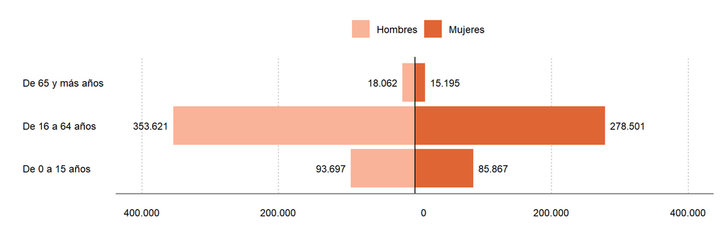

Nacionales de Marruecos con documentación de residencia según provincia de residencia. 31/12/2022

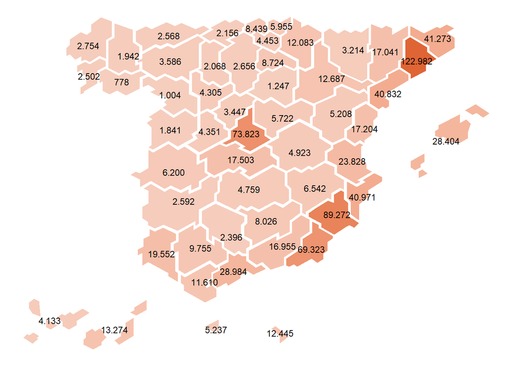

Fuente: [OPI - SGAM](https://www.inclusion.gob.es/web/opi/estadisticas/catalogo/extranjeros_con_certificado)

# 4. Afiliación en alta laboral y paro registrado

4.1 Régimen de afiliación a la Seguridad Social de nacionales de Marruecos a 28/04/2023

En España hay **333.469 afiliados de Marruecos**, que representan un 19,1% del total de ciudadanos de países no UE/AELC en alta laboral. 235.161 (71%) son hombres y 98.308 (29%) mujeres.

| Régimen | Afiliados de Marruecos | Afiliados no UE/AELC | % Marruecos sobre no UE/AELC |
| --- | --- | --- | --- |
| TOTAL | 333.469 | 1.745.903 | 19,1 |
| Régimen General | 183.137 | 288.480 | 63,5 |
| R.G. - S.E. Agrario | 111.750 | 157.985 | 70,7 |
| R.E. Autónomos/as | 27.665 | 35.396 | 78,2 |
| R.G. - S.E. Empleados/as hogar | 10.028 | 12.581 | 79,7 |
| R.E. Mar (cuenta ajena) | 885 | 2.630 | 33,7 |
| R.E. Mar (cuenta propia) | 4 | 10 | 40,0 |
| R.E. Minería carbón | 0 | 1 | 0,0 |

Afiliados nacionales de Marruecos en alta laboral según régimen y sexo. 28/04/2023

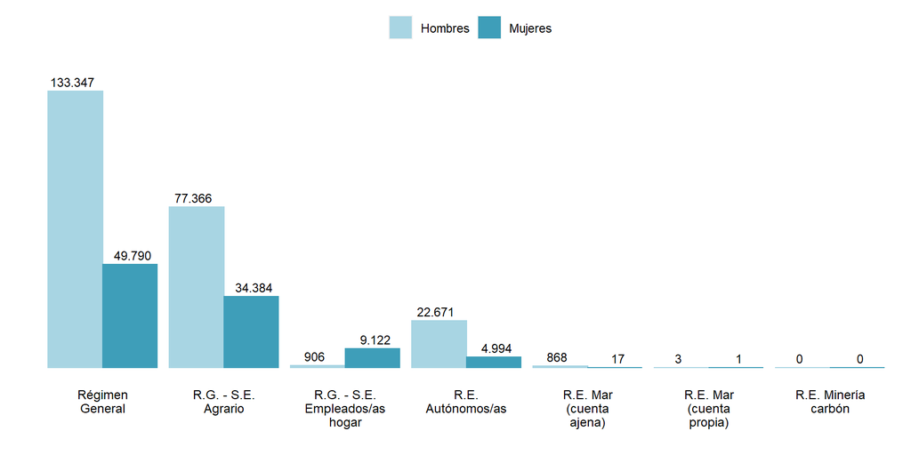

Fuente: [Seguridad Social - MISSM](https://www.seg-social.es/wps/portal/wss/internet/EstadisticasPresupuestosEstudios/Estadisticas/EST8/EST10/EST305/EST307/EST314)

4.2 Parados registrados en el SEPE nacionales de Marruecos (Abril 2023)

Hay en España **94.092 parados registrados nacionales de Marruecos**, 32.459 (34%) hombres y 61.633 (66%) mujeres.

| TOTAL | Sexo Hombres | Sexo Mujeres | Grupo de edad 16-24 años | Grupo de edad 25-34 años | Grupo de edad 35-44 años | Grupo de edad 45-54 años | Grupo de edad 55 y más años |
| --- | --- | --- | --- | --- | --- | --- | --- |
| 94.092 | 32.459 | 61.633 | 5.223 | 18.731 | 30.560 | 24.736 | 14.842 |
| % | 34 | 66 | 6 | 20 | 32 | 26 | 16 |

Parados registrados en el SEPE nacionales de Marruecos según comunidad autónoma. Abril 2023

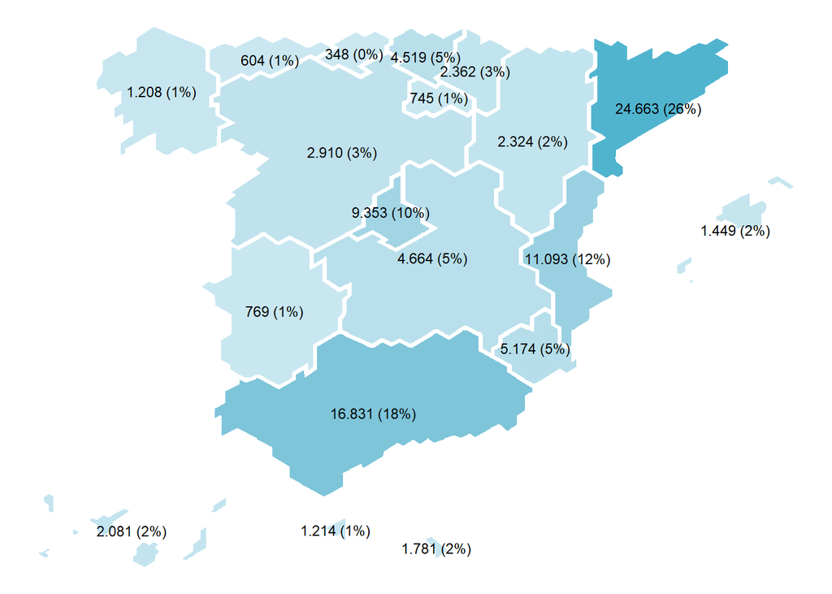

Fuente: [Servicio Público de Empleo Estatal (SEPE)](https://www.sepe.es/HomeSepe/que-es-el-sepe/estadisticas.html)

# 5. Nacionalizados españoles por residencia

**Desde 2009 se han nacionalizado españoles por residencia un total de 356.162 personas con nacionalidad previa marroquí.**

En 2022 obtuvieron la nacionalidad por residencia 46.257 personas.

Evolución de las concesiones de nacionalidad española por residencia a ciudadanos de Marruecos. 2009─2022

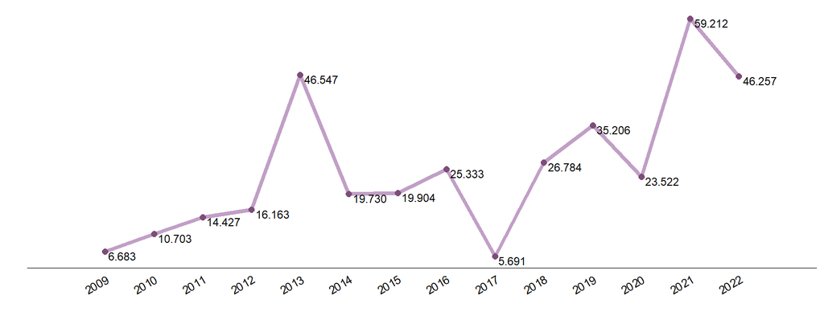

Nota: En 2017 hubo una reducción generalizada de las concesiones de nacionalidad por causas administrativas.

Concesiones de nacionalidad española por residencia a ciudadanos de Marruecos según plazo exigido / motivo. 2022

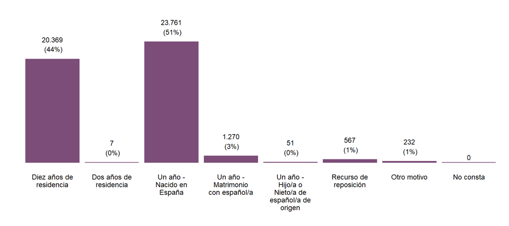

Nota: Existen casos en los que la nacionalidad de origen grabada no coincide con la vía de acceso a la nacionalidad española que debería corresponder según la legislación. Sin embargo, en este momento no se dispone de suficiente información para su correcta depuración.

Concesiones de nacionalidad española por residencia a ciudadanos de Marruecos según sexo y edad. 2022

| TOTAL | Hombres | % Hombres | Mujeres | % Mujeres |
| --- | --- | --- | --- | --- |
| 46.257 | 24.767 | 54 | 21.490 | 46 |

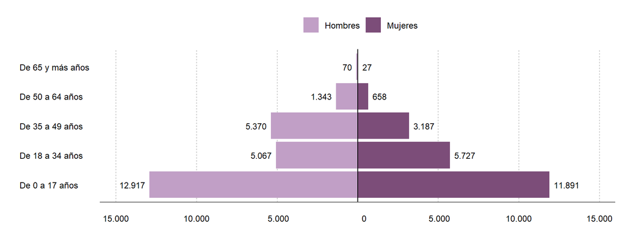

Fuente: [OPI - SGAM](https://www.inclusion.gob.es/web/opi/estadisticas/catalogo/concesiones_nacionalidad)

# 6. Solicitantes de Protección Internacional

**Durante 2022 3.905 personas nacionales de Marruecos solicitaron Protección Internacional** en el territorio de España, embajadas españolas, puestos fronterizos o CIE. Suponen un 3,3% del total de solicitantes del periodo.

Según avance mensual, **de enero a abril de 2023 solicitaron Protección Internacional 828 personas con nacionalidad Marruecos**, un 1,6% del total del periodo.

Evolución de los solicitantes de Protección Internacional nacionales de Marruecos y su distribución según sexo. 2017─2022

(No se han publicado aún datos desagregados por sexo para 2022)

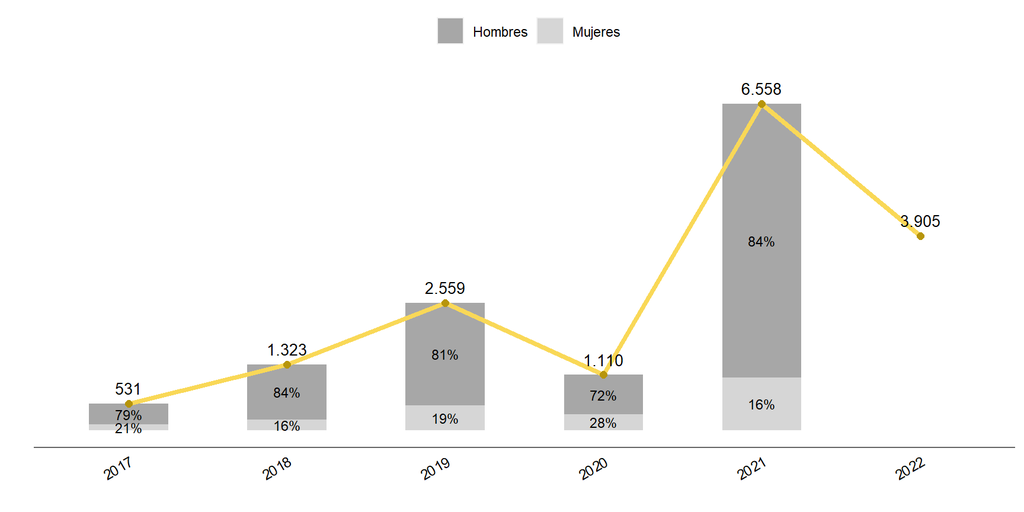

Solicitantes de Protección Internacional nacionales de Marruecos según lugar de presentación de la solicitud. 2021

(No se han publicado aún datos para 2022)

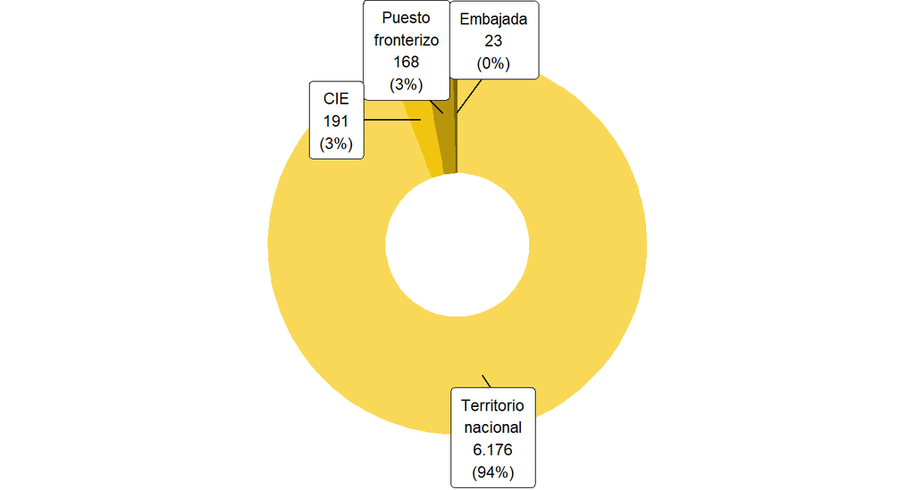

**Durante 2022 se resolvieron 3.776 solicitudes de Protección Internacional de personas con nacionalidad marroquí.** El 6% fueron favorables.

Evolución de las resoluciones de solicitudes de Protección Internacional de personas nacionales de Marruecos. 2017─2022

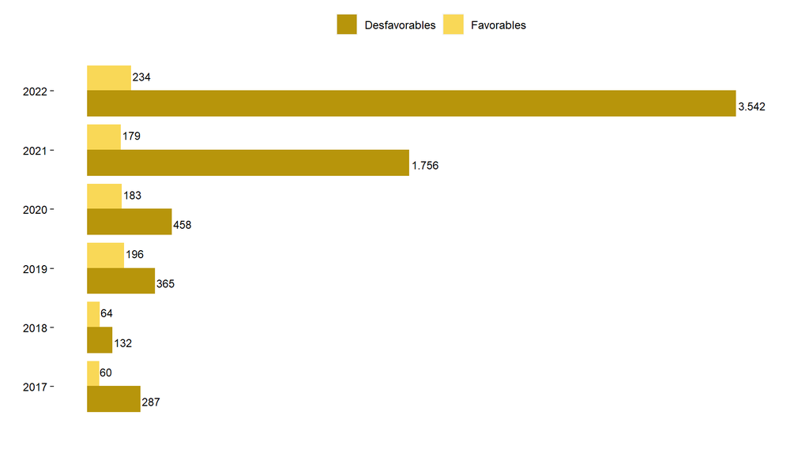

Tipo de resoluciones de solicitudes de Protección Internacional de personas nacionales de Marruecos. 2022

| Resolución | Personas | % |
| --- | --- | --- |
| TOTAL | 3.776 | 100 |
| Reconocimiento condición de refugiado | 231 | 6 |
| Reconocimiento derecho a la protección subsidiaria | 1 | 0 |
| Autor. estancia o residencia por razones humanitarias | 2 | 0 |
| Resolución desfavorable | 3.542 | 94 |

Propuestas de resolución de solicitudes de Protección Internacional de personas nacionales de Marruecos elevadas a la Comisión Interministerial de Asilo y Refugio. Enero─abril 2023

| Criterio de resolución | Propuestas | % |
| --- | --- | --- |
| TOTAL | 1.706 | 100 |
| Estatuto de refugiado | 128 | 8 |
| Protección subsidiaria | 0 | 0 |
| Razones humanitarias | 0 | 0 |
| Desfavorables | 1.497 | 88 |
| Archivo | 81 | 5 |

Fuente: [Oficina de Asilo y Refugio - Ministerio del Interior](https://www.interior.gob.es/opencms/es/servicios-al-ciudadano/tramites-y-gestiones/oficina-de-asilo-y-refugio/datos-e-informacion-estadistica/)

# 7. Beneficiarios del sistema de acogida y atención humanitaria

**Actualmente constan 2.225 personas de Marruecos en el Sistema de Acogida para Refugiados, Inmigrantes y Solicitantes de Asilo o en plazas de Atención Humanitaria**; suponen el 5,7% del total de beneficiarios. 1.902 (85%) hombres y 323 (15%) mujeres.

Nacionales de Marruecos beneficiarios del Sistema de Acogida o Atención Humanitaria según sexo y tipo de recurso. 30/05/2023

[output not shown]

Nacionales de Marruecos beneficiarios del Sistema de Acogida o Atención Humanitaria según comunidad autónoma de acogida. 30/05/2023

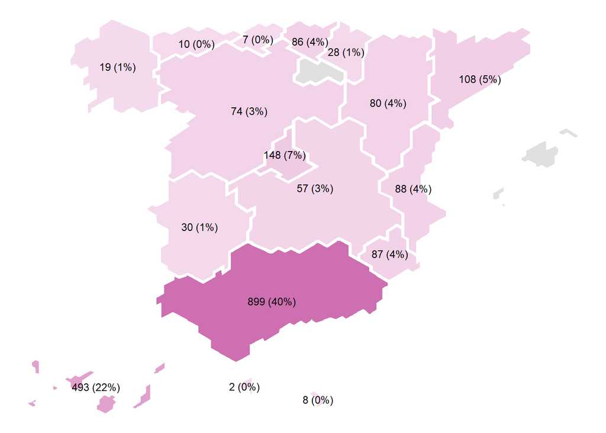

Fuente: SIRIA - MISSM

# 8. Menores no acompañados registrados en el Registro MENAs

**A 30/04/2023, última fecha disponible, había 3.643 menores no acompañados de Marruecos** registrados en el Registro MENAs del Ministerio de Interior, el 39,4% del total. 3.377 son chicos (93%) y 266 chicas (7%).

Menores no acompañados de Marruecos según comunidad autónoma de acogida. 30/04/2023

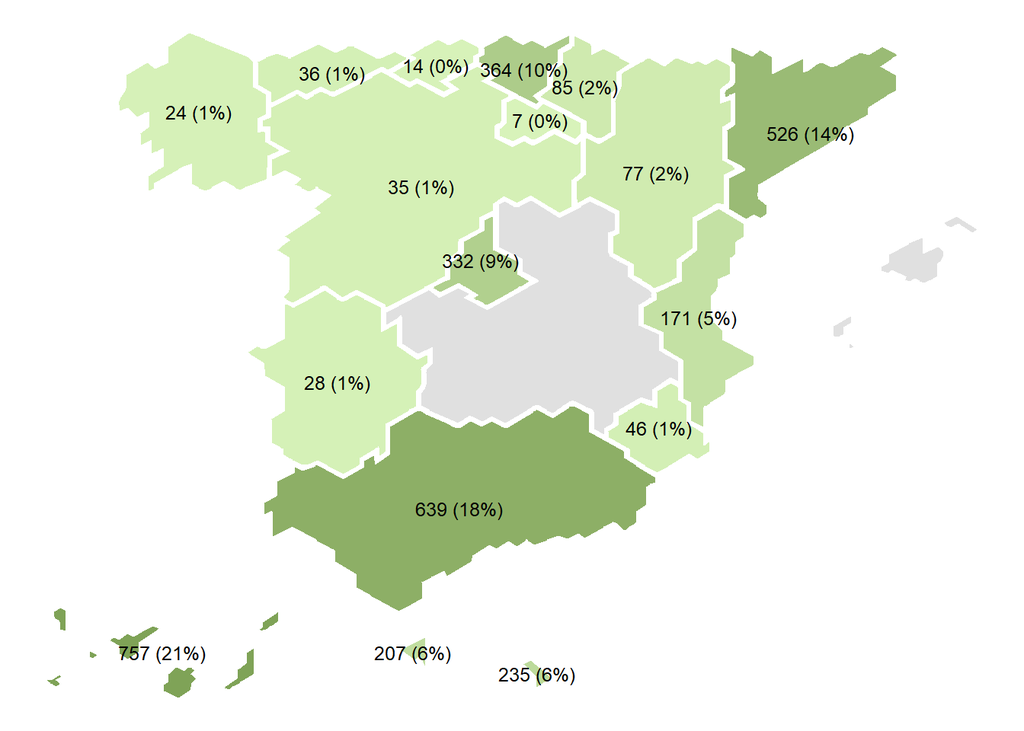

Evolución mensual del registro de menores no acompañados de Marruecos, abril 2021 ─ abril 2023

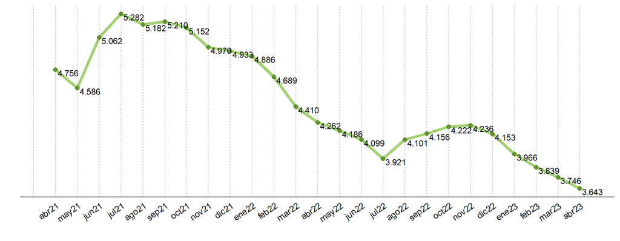

Fuente: Comisaría General de Extranjería y Fronteras - Ministerio del Interior

# 9. Evolución de los flujos regulares (visados y documentación de residencia)

9.1 Flujo de visados

Evolución de visados concedidos a ciudadanos de Marruecos según clase de visado. 2013─2022

| Clase | 2013 | 2014 | 2015 | 2016 | 2017 | 2018 | 2019 | 2020 | 2021 | 2022 | % 2022 |
| --- | --- | --- | --- | --- | --- | --- | --- | --- | --- | --- | --- |
| TOTAL | 130.859 | 137.604 | 153.340 | 166.708 | 179.501 | 194.175 | 211.828 | 84.899 | 89.533 | 183.707 | 100 |
| Corta duración | 121.587 | 128.180 | 141.611 | 152.359 | 160.619 | 161.653 | 172.190 | 50.068 | 53.068 | 144.666 | 79 |
| Larga duración | 9.267 | 9.422 | 11.724 | 14.346 | 18.877 | 32.518 | 39.633 | 34.831 | 36.465 | 39.037 | 21 |
| Tránsito aeroportuario | 5 | 2 | 5 | 3 | 5 | 4 | 5 | 0 | 0 | 4 | 0 |

Evolución de visados concedidos a ciudadanos de Marruecos según clase de visado de corta o larga duración. 2010─2022

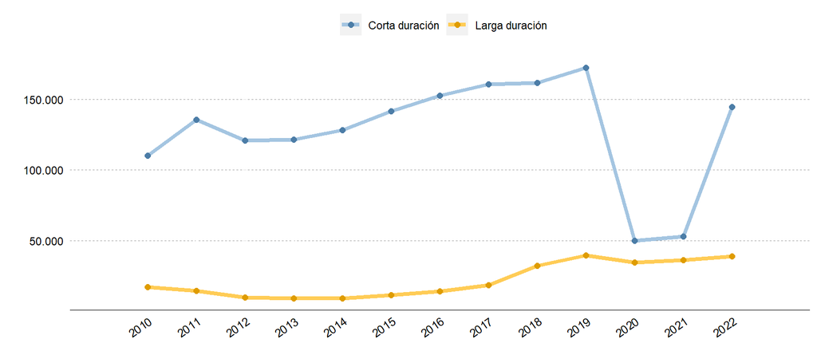

Visados expedidos a nacionales de Marruecos según clase (corta o larga duración) y tipo/finalidad de visado. 2022

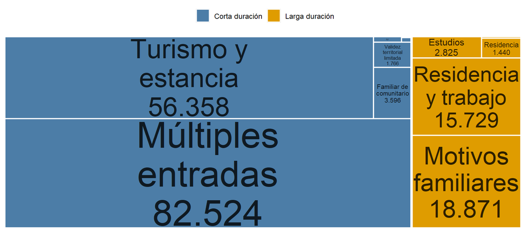

Fuente: [OPI - SGAM](https://www.inclusion.gob.es/web/opi/estadisticas/catalogo/visados)

Los visados de larga duración generalmente dan lugar a documentación de residencia.

9.2 Flujo de documentación de residencia

En los últimos 5 años se ha expedido documentación de residencia (autorizaciones de residencia y tarjetas de familiar de comunitario o de británico) a nacionales de Marruecos por los siguientes motivos:

Autorizaciones de residencia de Régimen General concedidas a ciudadanos de Marruecos según motivo. 2017─2021

| Motivo | 2017 | 2018 | 2019 | 2020 | 2021 |
| --- | --- | --- | --- | --- | --- |
| TOTAL | 71.114 | 85.514 | 91.175 | 104.672 | 119.135 |
| Residencia larga duración | 32.807 | 33.131 | 32.407 | 36.136 | 40.005 |
| Residencia temporal. Reagrupación familiar | 12.293 | 15.884 | 18.620 | 16.637 | 23.915 |
| Residencia temporal. Trabajo cuenta ajena | 8.506 | 8.754 | 10.258 | 12.268 | 14.397 |
| Residencia duración determinada. Trabajo cuenta ajena | 4.866 | 12.044 | 10.798 | 20.383 | 14.374 |
| Residencia temporal. Circunstancias excepcionales | 4.788 | 5.968 | 7.430 | 8.586 | 13.674 |
| Residencia temporal no lucrativa | 4.877 | 6.367 | 7.760 | 7.525 | 9.097 |
| Residencia larga duración-UE | 2.114 | 2.439 | 2.766 | 1.945 | 2.410 |
| Residencia temporal. Trabajo cuenta propia | 422 | 436 | 418 | 378 | 412 |
| Residencia temporal. Ley 14/2013 y otras | 135 | 154 | 261 | 274 | 399 |
| Residencia temporal. Compatibilidad cuenta ajena y propia | 236 | 227 | 245 | 272 | 309 |
| Residencia temporal. Excepción a la autorización de trabajo | 70 | 110 | 212 | 268 | 143 |

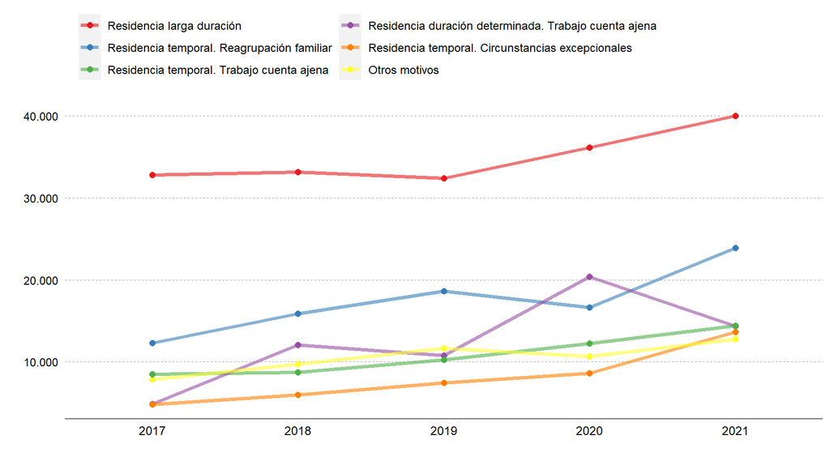

Tarjetas de familiar de ciudadano comunitario y TIE de familiar de británico beneficiario del acuerdo de retirada expedidas a nacionales de Marruecos, según motivo. 2017─2021

| Motivo | 2017 | 2018 | 2019 | 2020 | 2021 |
| --- | --- | --- | --- | --- | --- |
| TOTAL | 10.674 | 10.534 | 12.134 | 9.934 | 12.410 |
| Familiar de UE-RU. Temporal | 5.651 | 5.838 | 7.058 | 5.909 | 7.321 |
| Familiar de UE-RU. Permanente | 5.023 | 4.696 | 5.076 | 4.025 | 5.089 |

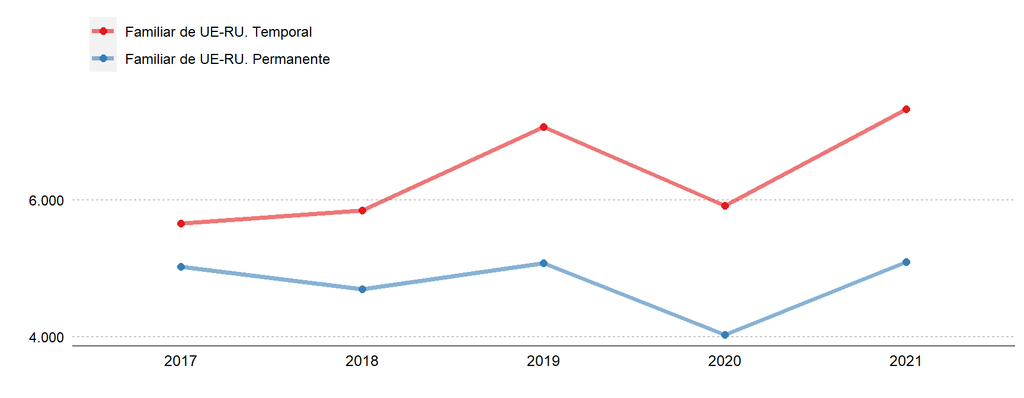

El siguiente gráfico muestra la **distribución de la documentación de residencia (autorizaciones de residencia y tarjetas de familiar de comunitario o de británico) concedida o expedida a nacionales de Marruecos durante 2021, según tipo de trámite**:

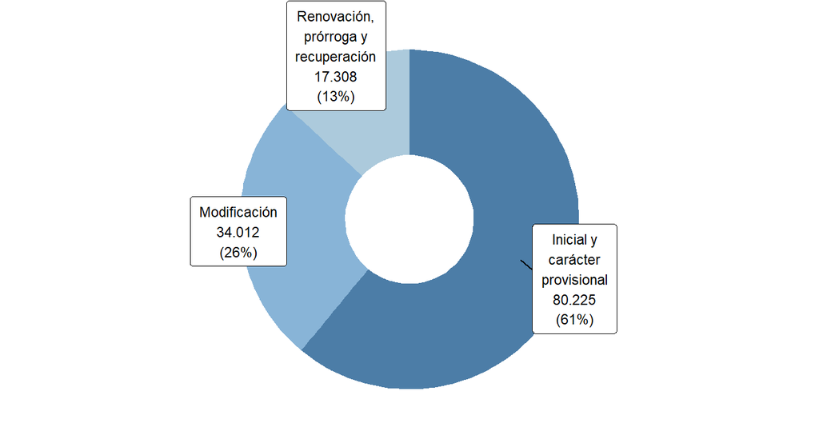

Fuente: [OPI - SGAM](https://www.inclusion.gob.es/web/opi/estadisticas/catalogo/flujo_autorizaciones)

**Comparando con el resto de países de la UE/AELC, el siguiente mapa muestra el número de *primeras* autorizaciones de residencia o de estancia por estudios expedidas a personas de nacionalidad marroquí durante 2021**, entendiendo como *primera* aquella autorización concedida a una persona si no le fue concedida ninguna otra en los 6 meses anteriores.

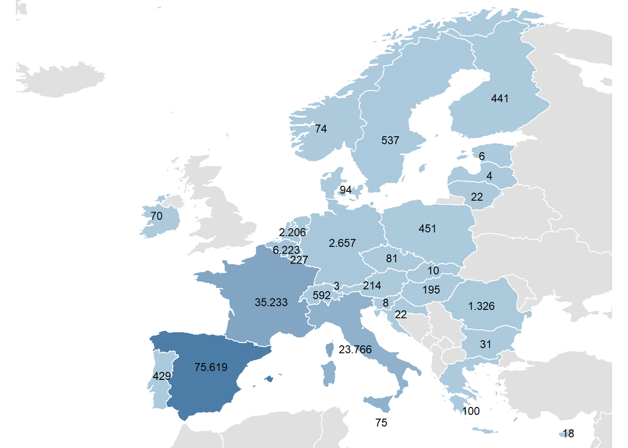

Sin dato disponible: Islandia

Fuente: [Eurostat](https://ec.europa.eu/eurostat/databrowser/view/migr_resfirst/default/table?lang=en)

# 10. Población española residente en Marruecos

**A 01/01/2023, último dato publicado por el INE, había 12.744 españoles residentes en Marruecos** inscritos en el fichero central del Padrón de españoles residentes en el extranjero (PERE); suponen el 42,9% de todos los españoles residentes en países de África.

| TOTAL | Hombres | % Hombres | Mujeres | % Mujeres |
| --- | --- | --- | --- | --- |
| 12.744 | 6.821 | 54 | 5.923 | 46 |

Evolución de los españoles residentes en Marruecos. 2009─2023

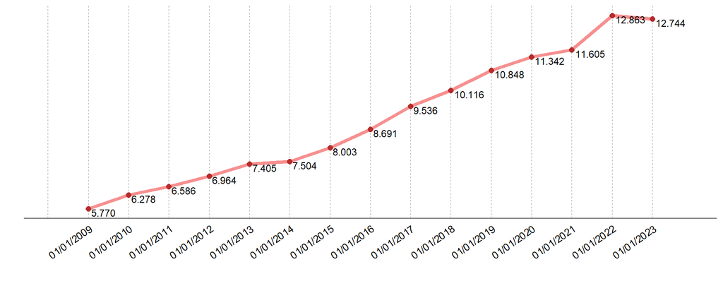

Fuente: [PERE - INE](https://www.ine.es/dyngs/INEbase/operacion.htm?c=Estadistica_C&cid=1254736177014&menu=resultados&secc=1254736195474&idp=1254734710990)